# Analysis of Lung Function Decline: 2-5 year follow-up in Whole Dataset Cohort

Weiji Su, Enas Ghulam, Emrah Gecili, Eleni-Rosalina Andrinopoulou, Rhonda Szczesniak

July 17, 2019

# 1 Analysis Cohort

In this analysis, there are 26692 subjects and 538931 observations. Mean (range) of follow-up time per patient was 4 (0, 5) years. Mean (range) number of observations was 20 (2, 161). The same number of patients and observations were utilized in each model below. We assume for each model that the data are missing at random, except for the joint longitudinal-survival model. The dependent variable is GLI FEV1 (% predicted) named “y” in the output below. The time scale is patients’ age at visit. Age is expressed in years. Age at CF diagnosis (in years) was included as a covariate in each model. Below are summary statistics for each variable used in the model. The graph below shows the frequency of deaths/lung transplants over follow up. Once a patient was recorded as having a lung transplant, his or her data were censored from the model.

```
##        y                Age        Age_Diag_per_patient
##  Min.   :  4.365   Min.   : 6.00   Min.   :-0.60
##  1st Qu.: 46.772   1st Qu.:11.99   1st Qu.: 0.10
##  Median : 71.012   Median :17.33   Median : 0.40
##  Mean   : 68.917   Mean   :19.55   Mean   : 2.19
##  3rd Qu.: 90.173   3rd Qu.:24.67   3rd Qu.: 2.40
##  Max.   :149.838   Max.   :76.65   Max.   :18.00
```

The Kaplan-Meier (KM) survival curve for those who died or received a lung transplant is plotted below showing the survival probability over age at visit (top graphic) and the number still alive/without lung transplant (bottom graphic).

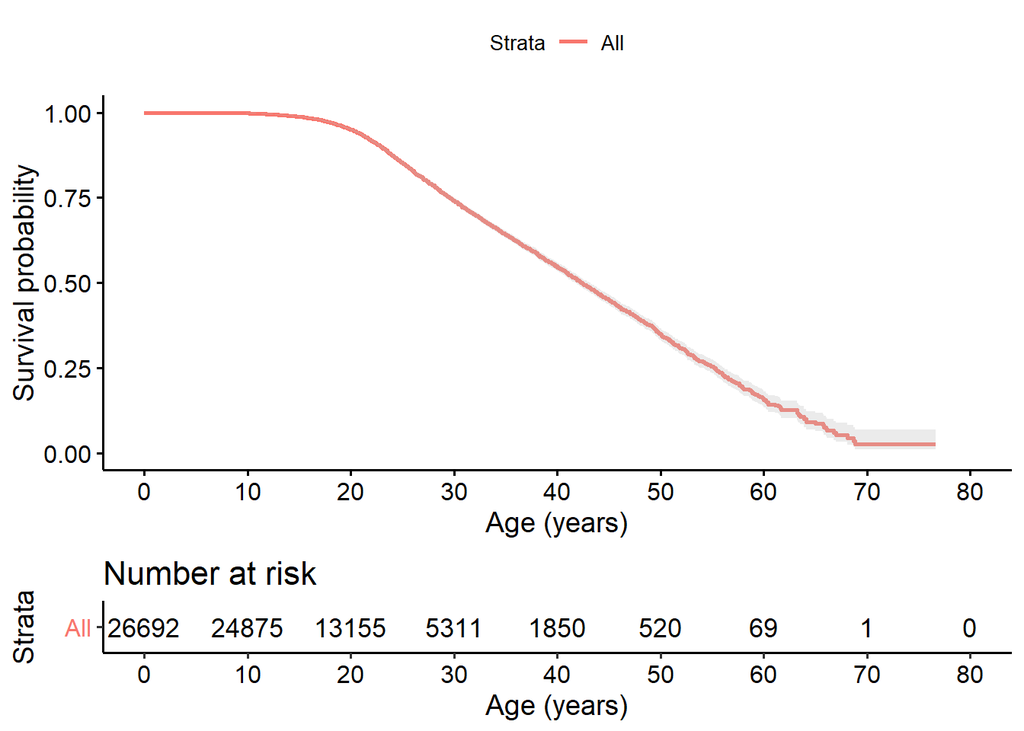

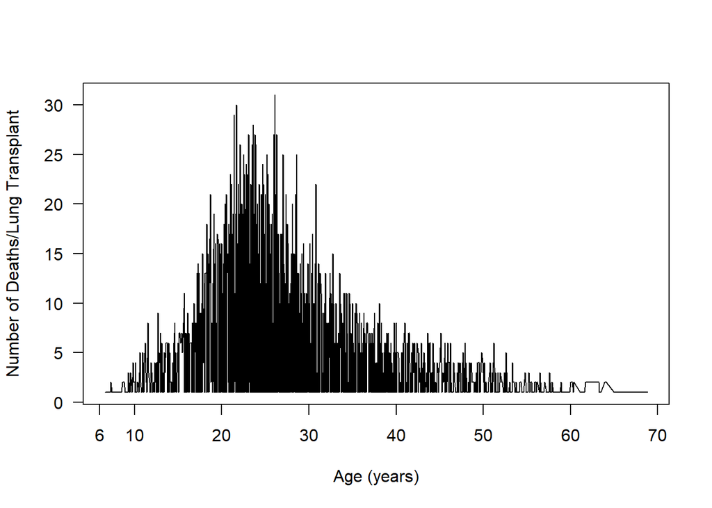

In the following report, we investigate three commonly used structures in CF FEV1 analysis. These include the linear mixed-effects model (LME), Generalized Estimating Equations (GEE) and joint modelling (JM). For the LME models, we include different combinations of random effects, splines and correlation structures as used in published CF studies (Section 2). We examine published GEE models combined with additional features for linearity/non-linearity (Section 3). We fit a joint model with the linear/non-linear structure from the LME models in Section 2.

# 2 Linear Mixed-Effects Model (LME)

## 2.1 LME Model with Random Intercept

### 2.1.1 Assumptions

Average evolution: A linear evolution is assumed over time.

Patient-specific evolution: A linear evolution is assumed over time. We assume that each patient may start from a different time point but all patients have the same evolution over time.

### 2.1.2 Model Estimation

```
## [1] "AIC =  4043503"
```

```
## [1] "BIC =  4043558"
```

Variance Components

|  | StdDev |
| --- | --- |
| (Intercept) | 21.928273 |
| Residual | 9.204632 |

|  | Value | Std.Error | DF | t-value | p-value |
| --- | --- | --- | --- | --- | --- |
| (Intercept) | 103.659 | 0.214 | 512238 | 483.748 | 0 |
| Age | -1.664 | 0.008 | 512238 | -211.195 | 0 |
| Age_Diag | 0.780 | 0.036 | 26690 | 21.452 | 0 |

As the coefficient estimate for ‘Age’ is around -1.664 % predicted/year, this means for one year increase in age, FEV1 is decreasing by 1.664 (unit % predicted).

### 2.1.3 Model Inference

We can calculate the population-level evolution (left) and rate of change (right) over time. As we have assumed a linear evolution, the left figure shows a straight line, corresponding to a linear estimated fit. The rate of change is calculated by taking first derivative of the model equation over time. This model estimates the rate of change in FEV1 as constant over different ages as -1.664.

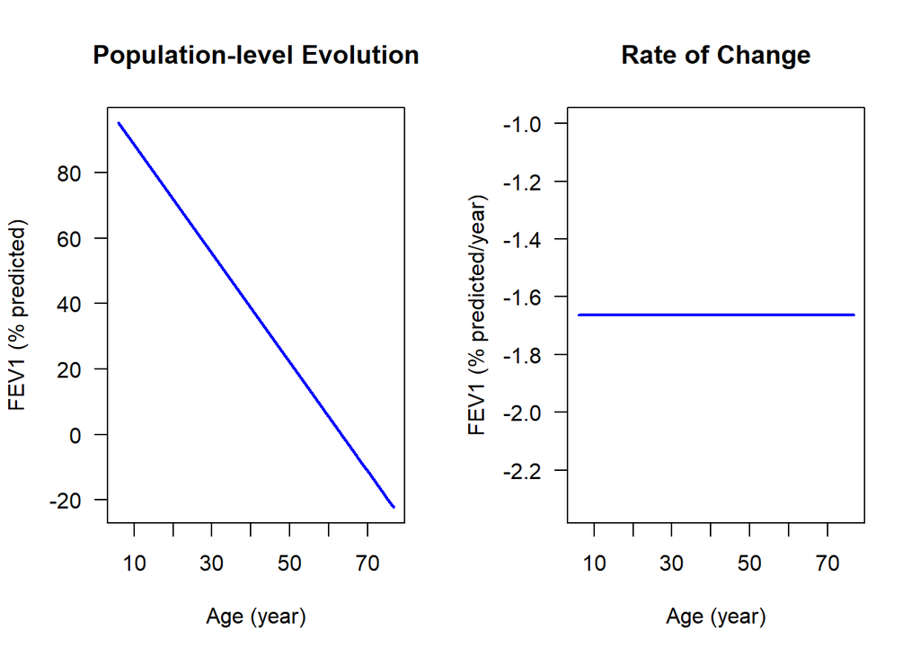

### 2.1.4 Model Diagnostics

We examined standardized residuals in terms of randomness, spread and nature of distribution.

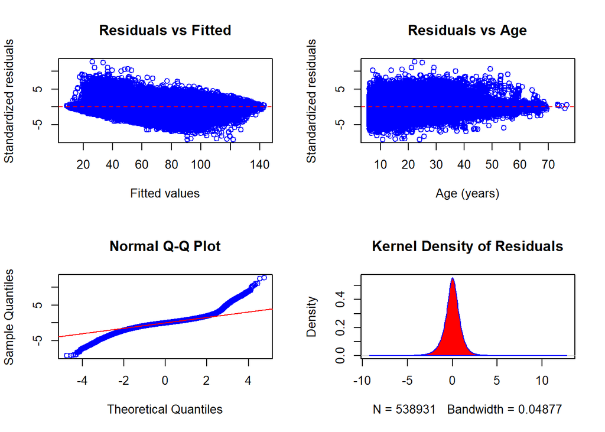

- The residuals vs fitted plot (upper left): are decreasing over the fitted values; that is, the smaller fitted values are being slightly underestimated, while the larger fitted values are being overestimated. This could be due to skewness in the FEV1 data.
- The residuals vs age (upper right): These are randomly scattered over time (age) and the mean over time roughly lies on the zero line, but the spread of the residuals is shrinking over time. This non-constant variance could due to the dropout for elder age (the survivor effect).
- The quantile-quantile (QQ) plot (lower left): We used the QQ plot to check the normality assumption, which compares quantiles of the standardized residuals to those from a standard normal distribution. Having all points along the diagonal line (red line in plot) would suggest that the residuals are approximately normally distributed. However, in this QQ plot, there is evidence that the distribution is heavier tailed where this feature is sometimes evident when modeling longitudinal data.
- The density of residuals (lower right): indicates the distribution of the residuals is symmetric. The heavier tails noted in the QQ plot are reflected in this plot. These diagnostics show the model is mainly valid, but further investigation may be needed to account for the fact that the variance decreases over fitted values and to accommodate the heavier tails.

## 2.2 LME Model with Random Intercept and Slope

### 2.2.1 Assumptions

Average evolution: A linear evolution is assumed over time.

Patient-specific evolution: A linear evolution is assumed over time. We assume that each patient may start from a different time point but all patients have different evolution over time.

### 2.2.2 Model Estimation

```
## [1] "AIC =  3990501"
```

```
## [1] "BIC =  3990580"
```

Variance Components

|  | StdDev |
| --- | --- |
| (Intercept) | 44.843490 |
| Age | 2.531842 |
| Residual | 8.368138 |

|  | Value | Std.Error | DF | t-value | p-value |
| --- | --- | --- | --- | --- | --- |
| (Intercept) | 104.287 | 0.337 | 512238 | 309.660 | 0 |
| Age | -1.695 | 0.018 | 512238 | -93.461 | 0 |
| Age_Diag | 0.502 | 0.046 | 26690 | 11.037 | 0 |

As the estimation of coefficient for ‘Age’ is around -1.695 % predicted/year, this means for one year increase in age, FEV1 is decreasing by 1.695 (unit % predicted).

### 2.2.3 Model Inference

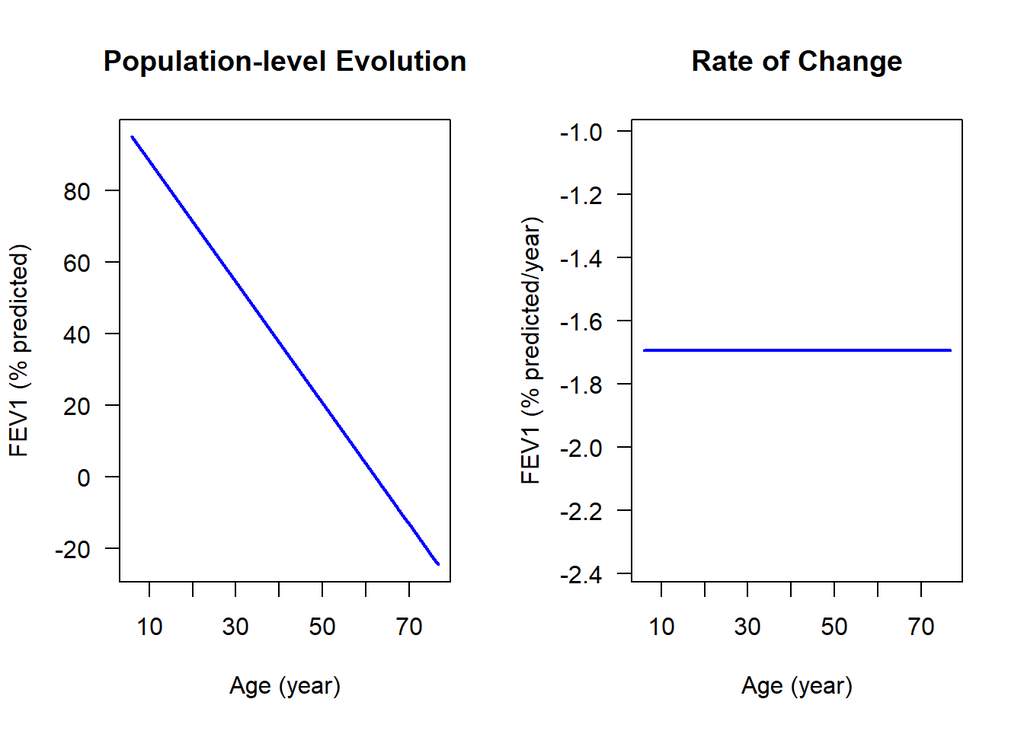

### 2.2.4 Model Diagnostics

The model diagnostic plots are below and they are similar to the previous pattern. And density of residuals (lower right) shows heavier tails and a bit positively skewed.

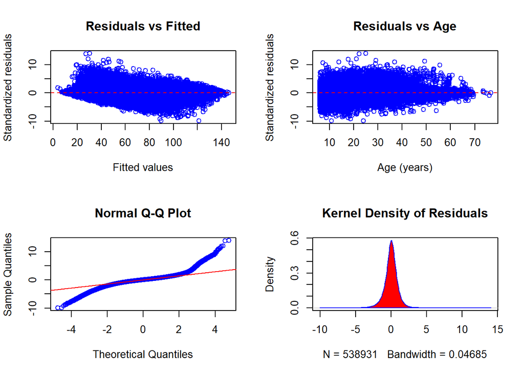

## 2.3 LME Model with 5-knot Natural Spline

### 2.3.1 Assumptions

Average evolution: A non-linear evolution (assuming cubic natural splines) is assumed over time.

Patient-specific evolution: A non-linear evolution (assuming cubic natural splines) is assumed over time. A diagonal variance-covariance matrix for the random effects are assumed. This means that the random effects are not correlated.

```
## [1] "Knots location (at age): 9.8, 13.5, 17.3, 21.4, 31.3"
```

### 2.3.2 Model Estimation

```
## [1] "AIC =  3968581"
```

```
## [1] "BIC =  3968760"
```

Variance Components

|  | StdDev |
| --- | --- |
| (Intercept) | 15.885794 |
| ns1 | 20.146015 |
| ns2 | 22.611435 |
| ns3 | 31.619499 |
| ns4 | 57.272446 |
| ns5 | 3.172106 |
| ns6 | 13.811165 |
| Residual | 8.149409 |

|  | Value | Std.Error | DF | t-value | p-value |
| --- | --- | --- | --- | --- | --- |
| (Intercept) | 91.105 | 0.215 | 512233 | 424.322 | 0 |
| ns1 | -11.583 | 0.267 | 512233 | -43.328 | 0 |
| ns2 | -15.178 | 0.341 | 512233 | -44.560 | 0 |
| ns3 | -32.261 | 0.403 | 512233 | -80.132 | 0 |
| ns4 | -51.111 | 0.815 | 512233 | -62.704 | 0 |
| ns5 | -62.808 | 0.975 | 512233 | -64.395 | 0 |
| ns6 | -71.731 | 1.819 | 512233 | -39.425 | 0 |
| Age_Diag | 0.657 | 0.040 | 26690 | 16.299 | 0 |

### 2.3.3 Model Inference

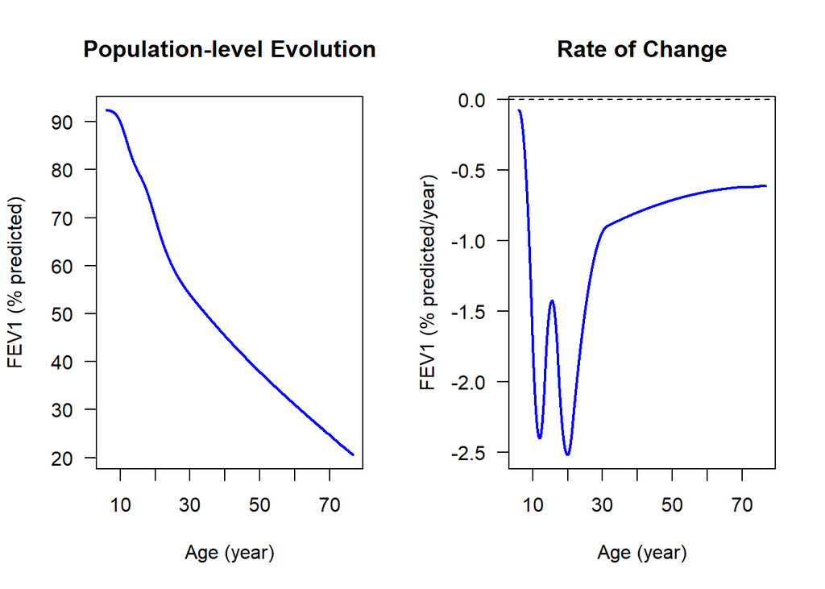

### 2.3.4 Model Diagnostics

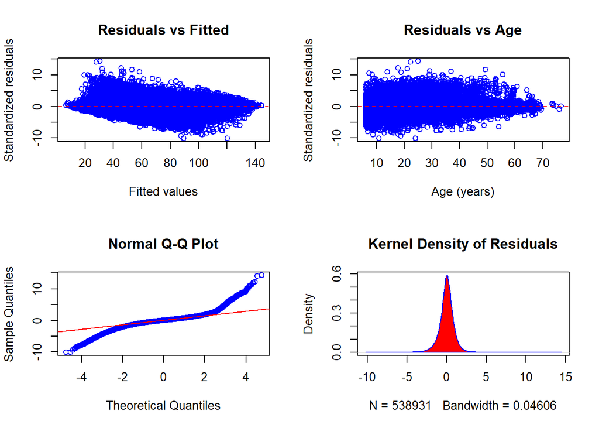

## 2.4 Linear Random Intercepts with Exponential Correlation

### 2.4.1 Assumptions

Average evolution: A linear mean evolution is assumed over time.

Patient-specific evolution: A linear evolution is assumed over time. We assume that each patient may start from a different time point but all patients have the same evolution over time. Correlation structure: exponential correlation function. This means that, for each subject, the correlation of FEV1 exponentially decays to zero with the distance between times (ages).

### 2.4.2 Model Estimation

```
## [1] "AIC =  3939718"
```

```
## [1] "BIC =  3939796"
```

Variance Components

|  | StdDev |
| --- | --- |
| (Intercept) | 18.03172 |
| Residual | 15.01588 |

```
## Correlation Structure: Exponential spatial correlation
##  Formula: ~Age | eDWID
##  Parameter estimate(s):
##     range    nugget
## 6.7040761 0.2328758
```

|  | Value | Std.Error | DF | t-value | p-value |
| --- | --- | --- | --- | --- | --- |
| (Intercept) | 98.958 | 0.259 | 512238 | 381.979 | 0 |
| Age | -1.396 | 0.011 | 512238 | -124.060 | 0 |
| Age_Diag | 0.629 | 0.036 | 26690 | 17.517 | 0 |

As the estimation of the coefficient for ‘Age’ is around -1.396 % predicted/year, this means for one year increase in age, FEV1 is decreasing by 1.396 (unit % predicted).

### 2.4.3 Model Inference

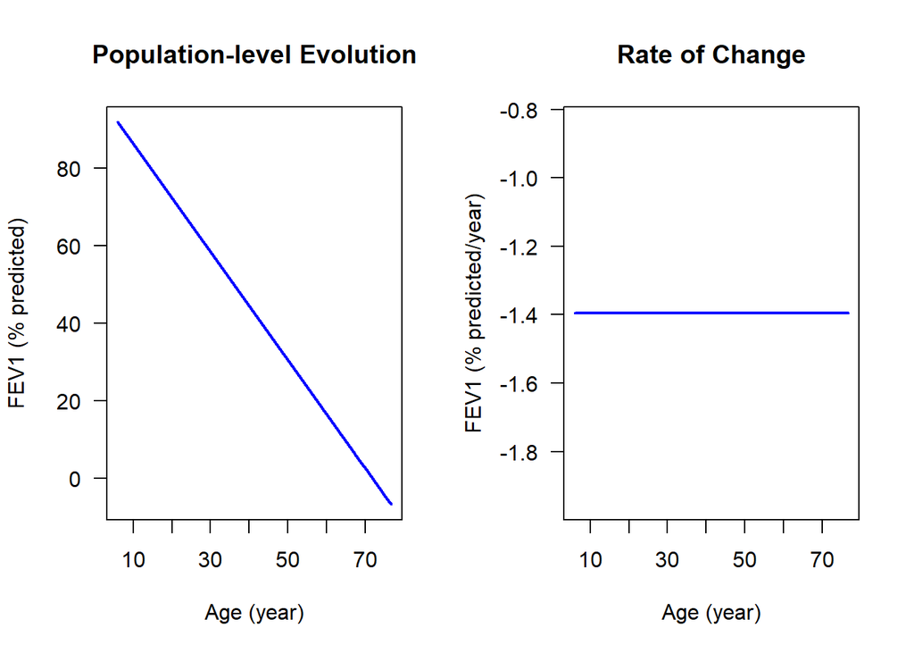

### 2.4.4 Model Diagnostics

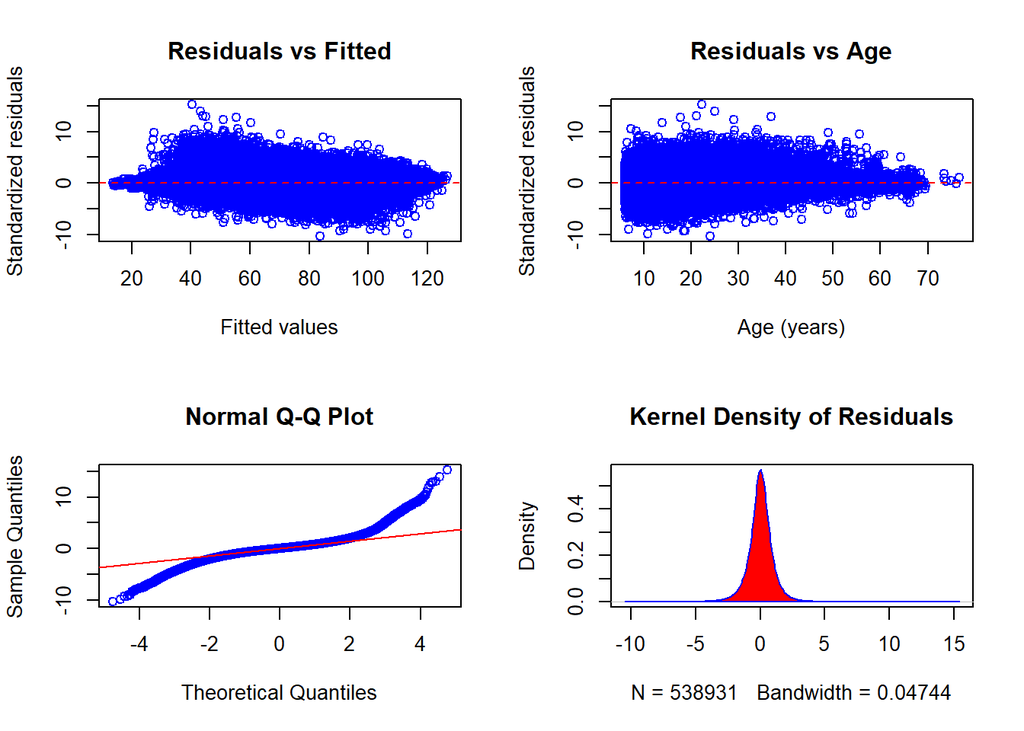

## 2.5 Spline Random Intercept with Exponential Correlation

### 2.5.1 Assumptions

Average evolution: A non-linear evolution (assuming cubic natural splines) is assumed over time.

Patient-specific evolution: A linear evolution is assumed over time and each patient may start at different time point

Correlation structure: exponential correlation function. This means that, for each subject, the correlation of FEV1 exponentially decays to zero with the distance between times (age).

### 2.5.2 Model Estimation

```
## [1] "Knots location (at age): 9.8, 13.5, 17.3, 21.4, 31.3"
```

```
## [1] "AIC =  3937673"
```

```
## [1] "BIC =  3937808"
```

Variance Components

|  | StdDev |
| --- | --- |
| (Intercept) | 17.89048 |
| Residual | 14.42543 |

```
## Correlation Structure: Exponential spatial correlation
##  Formula: ~Age | eDWID
##  Parameter estimate(s):
##     range    nugget
## 6.0394886 0.2523741
```

|  | Value | Std.Error | DF | t-value | p-value |
| --- | --- | --- | --- | --- | --- |
| (Intercept) | 90.678 | 0.279 | 512233 | 325.064 | 0 |
| ns1 | -10.868 | 0.300 | 512233 | -36.194 | 0 |
| ns2 | -14.577 | 0.351 | 512233 | -41.512 | 0 |
| ns3 | -32.913 | 0.398 | 512233 | -82.638 | 0 |
| ns4 | -46.322 | 0.874 | 512233 | -52.994 | 0 |
| ns5 | -51.780 | 1.312 | 512233 | -39.457 | 0 |
| ns6 | -56.622 | 2.632 | 512233 | -21.515 | 0 |
| Age_Diag | 0.587 | 0.035 | 26690 | 16.688 | 0 |

### 2.5.3 Model Inference

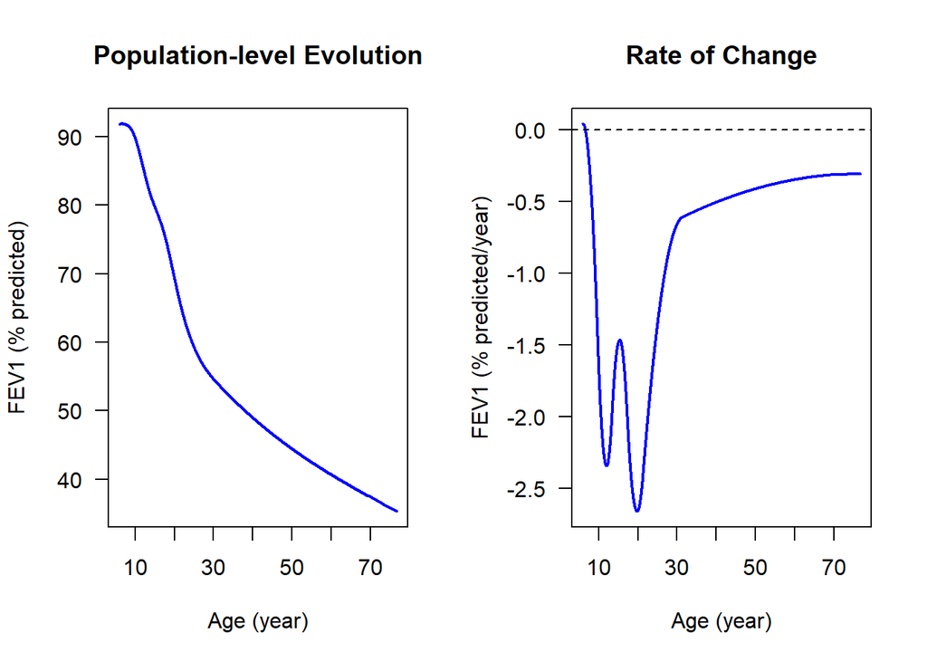

### 2.5.4 Model Diagnostics

The diagnostics plots show fairly similar pattern with the previous model.

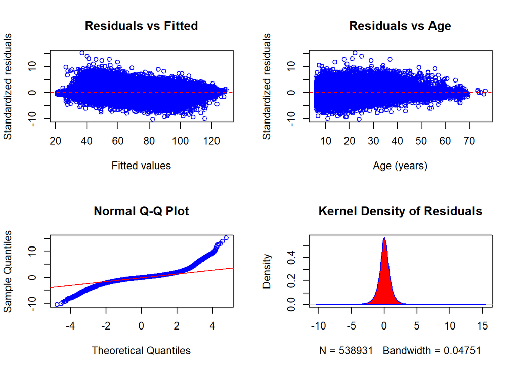

# 3 Linear Generalized Estimating Equations Model (GEE)

Compared with LME models, GEE models allow for weaker distributional assumptions and are more robust to covariance misspecification. In this analysis, the average evolution (fixed-effects) structure in the GEE model was selected based on the performance of all LME models. This GEE model is fitted with a linear structure to model the mean evolution and accounts for longitudinal correlation using the sandwich estimator.

## 3.1 Assumptions

Average evolution: A linear evolution (assuming natural cubic splines) is used over time.

Patient-specific evolution: A linear evolution is assumed over time and each patient may start at different time point.

Correlation structure: independence (working) correlation function.

## 3.2 Model Estimation

Coefficients:

|  | Estimate | Std.err | Wald | Pr(>\|W\|) |
| --- | --- | --- | --- | --- |
| (Intercept) | 93.666 | 0.333 | 79254.373 | 0 |
| Age | -1.324 | 0.015 | 7921.738 | 0 |
| Age_Diag | 0.570 | 0.043 | 174.565 | 0 |

Estimated Scale Parameters:

|  | Estimate | Std.err |
| --- | --- | --- |
| (Intercept) | 547.678 | 4.068 |

## 3.3 Model Inference

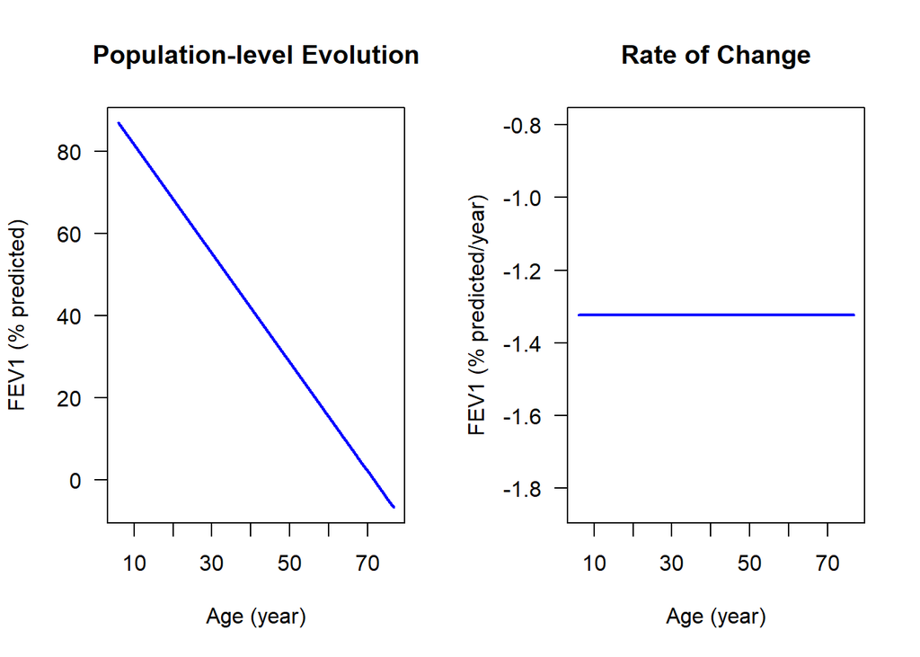

## 3.4 Model Diagnostics

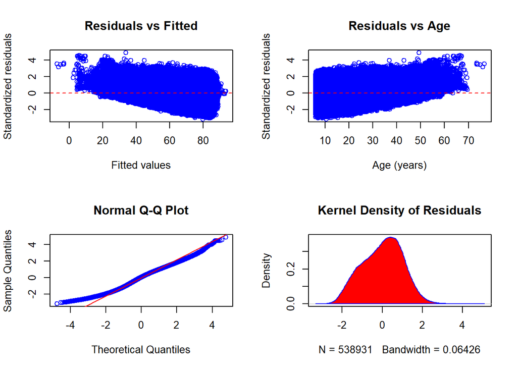

- The residuals vs fitted plot (upper left): has a decreasing trend over the fitted values showing a sparsity around value 0 of fitted value and a majority round the 60 to 80 of the fitted value.
- The residuals vs age (upper right): is increasing over time (age), suggesting the potential for heteroscedasticity (i.e., non-constant variance over time).
- The quantile-quantile (QQ) plot (lower left): The Q-Q plot shows the points at smaller quantiles are a bit off the diagonal line and other points are along the diagonal line which indicates residuals approximate the unit normal distribution, which suggests that the relaxed assumptions in GEE model alleviate issues with heavy tails.
- The density of residuals (lower right): has heavier tails in both sides and is not symmetric.

# 4 Non-linear Generalized Estimating Equations Model (GEE)

In this analysis, the GEE mode is fitted with a spline structure to model the mean evolution and includes an independence correlation.

## 4.1 Assumptions

Average evolution: A non-linear evolution (assuming cubic natural splines) is used over time.

Patient-specific evolution: A linear evolution is assumed over time and each patient may start at different time point.

Correlation structure: independence correlation function (sandwich estimator used to account for longitudinal correlation).

## 4.2 Model Estimation

Coefficients:

|  | Estimate | Std.err | Wald | Pr(>\|W\|) |
| --- | --- | --- | --- | --- |
| (Intercept) | 90.824 | 0.558 | 26521.946 | 0 |
| ns1 | -15.859 | 0.761 | 434.095 | 0 |
| ns2 | -23.107 | 0.817 | 800.307 | 0 |
| ns3 | -36.788 | 0.782 | 2213.137 | 0 |
| ns4 | -44.767 | 1.366 | 1074.691 | 0 |
| ns5 | -53.330 | 1.948 | 749.792 | 0 |
| ns6 | -54.808 | 3.566 | 236.274 | 0 |
| Age_Diag | 0.565 | 0.042 | 184.875 | 0 |

Estimated Scale Parameters:

|  | Estimate | Std.err |
| --- | --- | --- |
| (Intercept) | 519.993 | 4.031 |

## 4.3 Model Inference

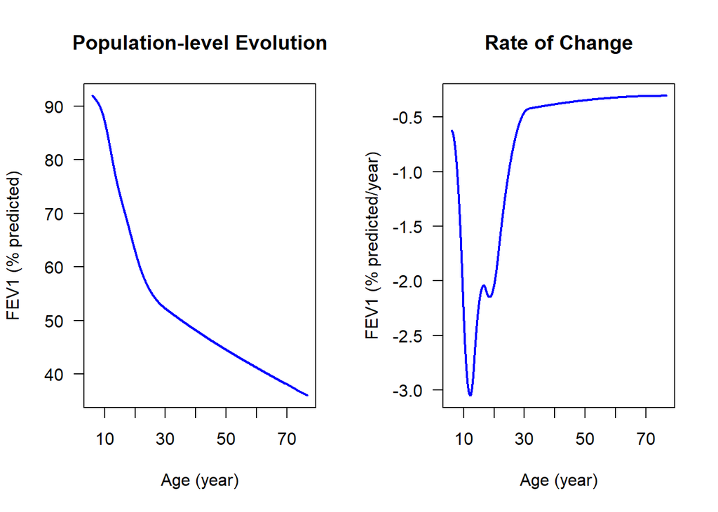

## 4.4 Model Diagnostics

The diagnostic plots show a similar pattern as in the the previous GEE model.

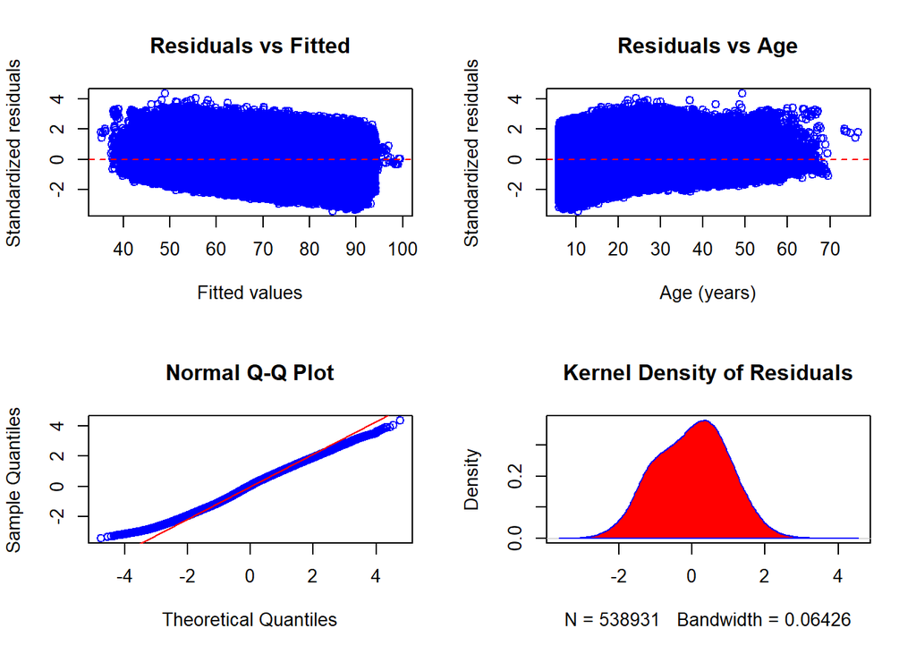

# 5 Linear Joint Model of Longitudinal FEV1 (% predicted) and Survival (JM)

Missing data due to death or lung transplant is accounted for by jointly modeling the FEV1 process with the survival process using a Weibull model for survival. We use a Weibull baseline risk function to fit the baseline hazard in the survival sub-model. This joint model was implemented using the shared parameter framework. The shared parameters here corresponded to connecting the survival outcome with the underlying value of FEV1 and rate of change in FEV1 over time.

## 5.1 Assumptions

We assume that FEV1 and survival are associated over time (age). To fit the longitudinal sub-model for FEV1, we apply the LME model with linear assumption; for survival, we use the Weibull survival model.

Average evolution of FEV1: A linear evolution is assumed over time.

Survival Baseline hazard: A Weibull baseline risk hazard is assumed over time at baseline.

Association: We assume the underlying value of FEV1 and rate of change over time to be associated with survival.

## 5.2 Model Estimation and Interpretation

```
## [1] "AIC =  4025363"
```

```
## [1] "BIC =  4025461"
```

The variance components for FEV1 include the standard deviations of the random intercept as “(Intercept)”, slope as “Age” and residual as “Residual” reported below.

Variance Components

|  | StdDev |
| --- | --- |
| (Intercept) | 42.873 |
| Age | 2.524 |
| Residual | 8.384 |

Longitudinal Process

|  | Value | Std.Err | z-value | p-value |
| --- | --- | --- | --- | --- |
| (Intercept) | 104.895 | 0.271 | 387.421 | 0 |
| Age | -1.720 | 0.013 | -135.023 | 0 |
| Age_Diag | 0.520 | 0.041 | 12.633 | 0 |

Event Process

|  | Value | p-value | Hazard Ratio | Lower | Upper |
| --- | --- | --- | --- | --- | --- |
| (Intercept) | -10.032 | 0 | 0.000 | 0.000 | 0.000 |
| Age_Diag | -0.053 | 0 | 0.949 | 0.940 | 0.957 |
| Assoct | -0.052 | 0 | 0.949 | 0.948 | 0.950 |
| Assoct.s | -0.350 | 0 | 0.704 | 0.697 | 0.712 |
| log(shape) | 1.123 | 0 | 3.075 | 3.002 | 3.149 |

## 5.3 Model Inference

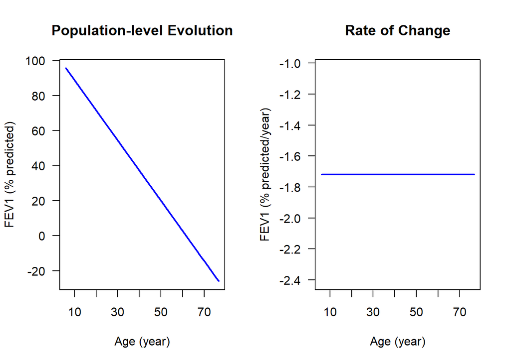

## 5.4 Model Diagnostics

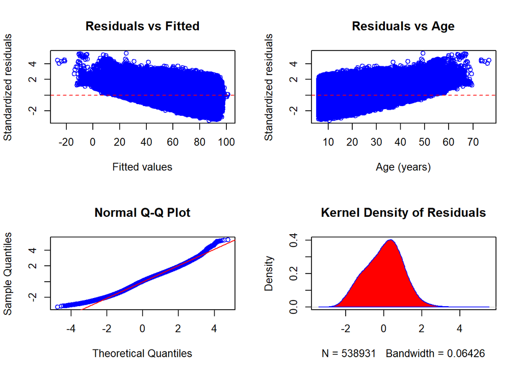

# 6 Non-linear Joint Model of Longitudinal FEV1(% predicted) and Survival (JM)

## 6.1 Assumptions

Average evolution of FEV1: A non-linear evolution by cubic natural spline is assumed over time.

Survival Baseline hazard: A Weibull baseline risk hazard is assumed over time at baseline.

Association: We assume the underlying value of FEV1 and rate of change over time to be associated with survival.

## 6.2 Model Estimation and Interpretation

```
## [1] "AIC =  4023937"
```

```
## [1] "BIC =  4024076"
```

Variance Components

|  | StdDev |
| --- | --- |
| (Intercept) | 42.515 |
| Age | 2.480 |
| Residual | 8.377 |

Longitudinal Process

|  | Value | Std.Err | z-value | p-value |
| --- | --- | --- | --- | --- |
| (Intercept) | 89.982 | 0.301 | 299.281 | 0 |
| ns(Age, knots = c(9.8, 13.5, 17.3, 21.4, 31.3))1 | -10.119 | 0.264 | -38.384 | 0 |
| ns(Age, knots = c(9.8, 13.5, 17.3, 21.4, 31.3))2 | -13.153 | 0.312 | -42.211 | 0 |
| ns(Age, knots = c(9.8, 13.5, 17.3, 21.4, 31.3))3 | -29.843 | 0.352 | -84.835 | 0 |
| ns(Age, knots = c(9.8, 13.5, 17.3, 21.4, 31.3))4 | -54.704 | 0.507 | -107.980 | 0 |
| ns(Age, knots = c(9.8, 13.5, 17.3, 21.4, 31.3))5 | -86.105 | 0.595 | -144.631 | 0 |
| ns(Age, knots = c(9.8, 13.5, 17.3, 21.4, 31.3))6 | -114.279 | 0.986 | -115.866 | 0 |
| Age_Diag | 0.594 | 0.023 | 25.648 | 0 |

Event Process

|  | Value | p-value | Hazard Ratio | Lower | Upper |
| --- | --- | --- | --- | --- | --- |
| (Intercept) | -10.066 | 0 | 0.000 | 0.000 | 0.000 |
| Age_Diag | -0.054 | 0 | 0.948 | 0.939 | 0.956 |
| Assoct | -0.054 | 0 | 0.948 | 0.947 | 0.949 |
| Assoct.s | -0.349 | 0 | 0.706 | 0.698 | 0.714 |
| log(shape) | 1.135 | 0 | 3.110 | 3.035 | 3.186 |

## 6.3 Model Inference

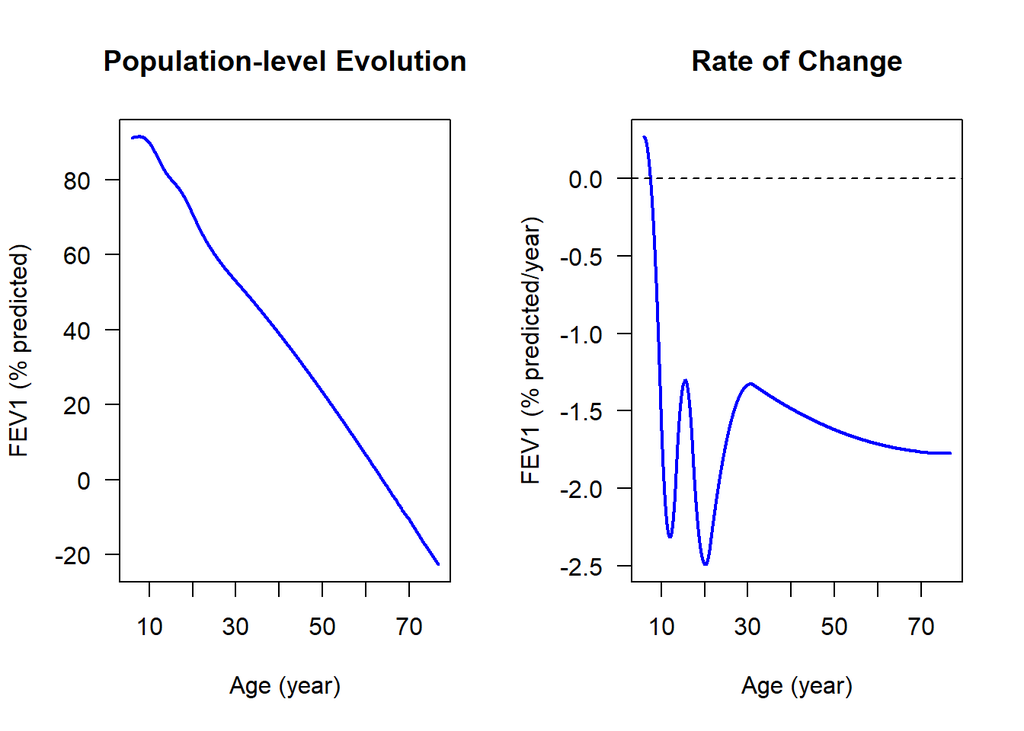

## 6.4 Model Diagnostics

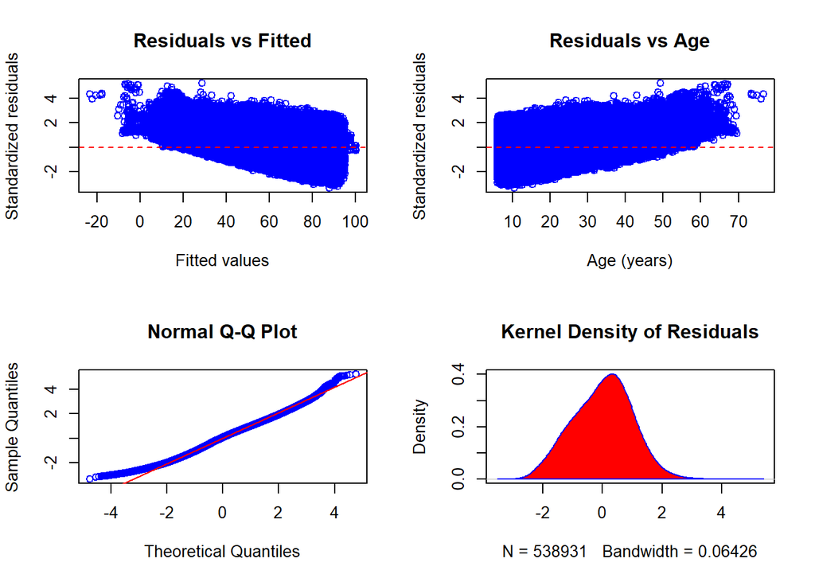

# 7 Plot Population-level FEV1 (% predicted) Estimation for All Models

| Model Name Abbreviation Name | Model Name Abbreviation Specification |
| --- | --- |
| Int | Linear evolution with random intercept |
| Int + Slope | Linear evolution with random intercept and slope |
| Spline | Non-linear evolution by using spline as both average evolution and random effect |
| Int + Corr | Linear evolution with random intercept and exponential correlation structure |
| Spline + Corr | Non-linear evolution with spline as average evolution, random intercept and exponential correlation structure |
| Lin_GEE | Linear evolution with independence correlation structure |
| Nonlin_GEE | Non-linear evolution by using spline with independence correlation structure |
| Lin_JM | Linear evolution with jointly model FEV and survival |
| Nonlin_JM | Non-linear evolution with jointly model FEV and survival |

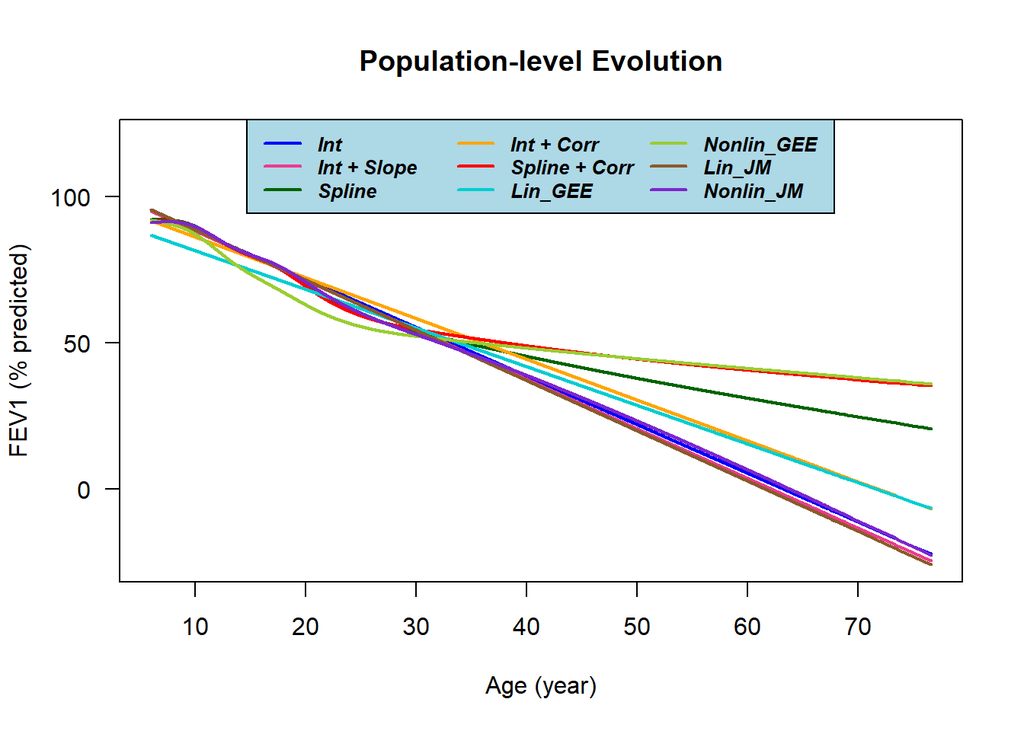

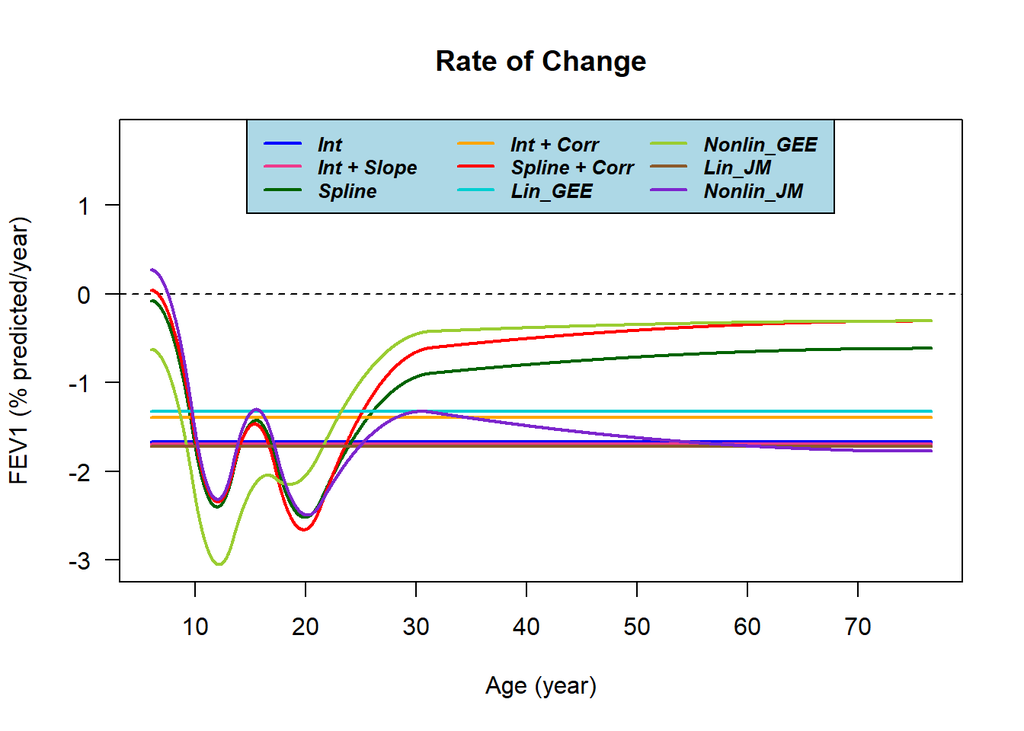

To check more closely, we zoom in the result for age 6 to 30.

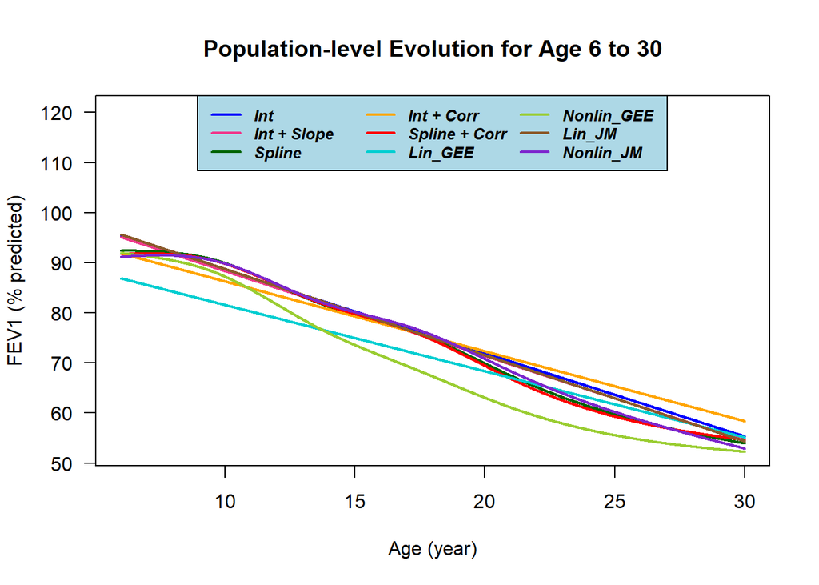

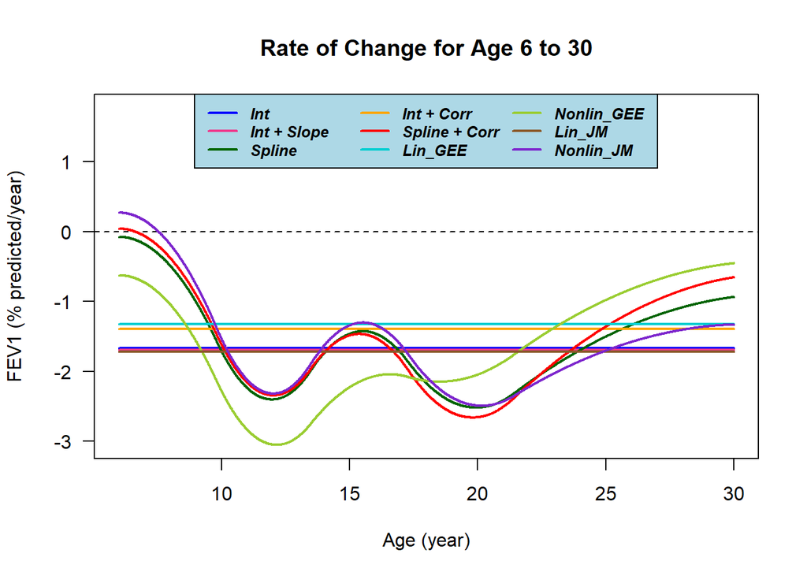